# Figure 3. Diverse bacterial genera consistently correlated with tiller numbers in field-grown rice

Yong-Xin Liu

2021-12-15

# Figure 3. Diverse bacterial genera consistently correlated with tiller numbers in field-grown rice

## 3A/B. Overlap of bacterial genera negatively (A) or positively (B) correlated with tiller numbers of rice varieties grown in the two test fields.

```r
LN = read.table("../data/cultivar_LN_genus_cor_tiller_spearman.txt", header=T, row.names=1, sep="\t", comment.char="")
HN = read.table("../data/cultivar_HN_genus_cor_tiller_spearman.txt", header=T, row.names=1, sep="\t", comment.char="")
# Delete Unassigned
idx = rownames(LN) %in% "Unassigned"
LN = LN[!idx,]
idx = rownames(HN) %in% "Unassigned"
HN = HN[!idx,]

# Select significantly correlated genus in field I/II
LN_postive = LN[LN$FDR<0.05 & LN$rho>0,]
LN_negative = LN[LN$FDR<0.05 & LN$rho<0,]
HN_postive = HN[HN$FDR<0.05 & HN$rho>0,]
HN_negative = HN[HN$FDR<0.05 & HN$rho<0,]
suppressWarnings(write.table(paste("FieldI_postive", rownames(LN_postive),sep="\t"), file=paste("../data/genus_sig_cor_list.txt",sep = ""), append = F, sep="\t", quote=F, row.names=F, col.names=F))
suppressWarnings(write.table(paste("FieldI_negative", rownames(LN_negative),sep="\t"), file=paste("../data/genus_sig_cor_list.txt",sep = ""), append = T, sep="\t", quote=F, row.names=F, col.names=F))
suppressWarnings(write.table(paste("FieldII_postive", rownames(HN_postive),sep="\t"), file=paste("../data/genus_sig_cor_list.txt",sep = ""), append = T, sep="\t", quote=F, row.names=F, col.names=F))
suppressWarnings(write.table(paste("FieldII_negative", rownames(HN_negative),sep="\t"), file=paste("../data/genus_sig_cor_list.txt",sep = ""), append = T, sep="\t", quote=F, row.names=F, col.names=F))
```

Visualized in http://www.ehbio.com/test/venn/#/

Save figure as venn_fieldLH_Negative.svg/csv

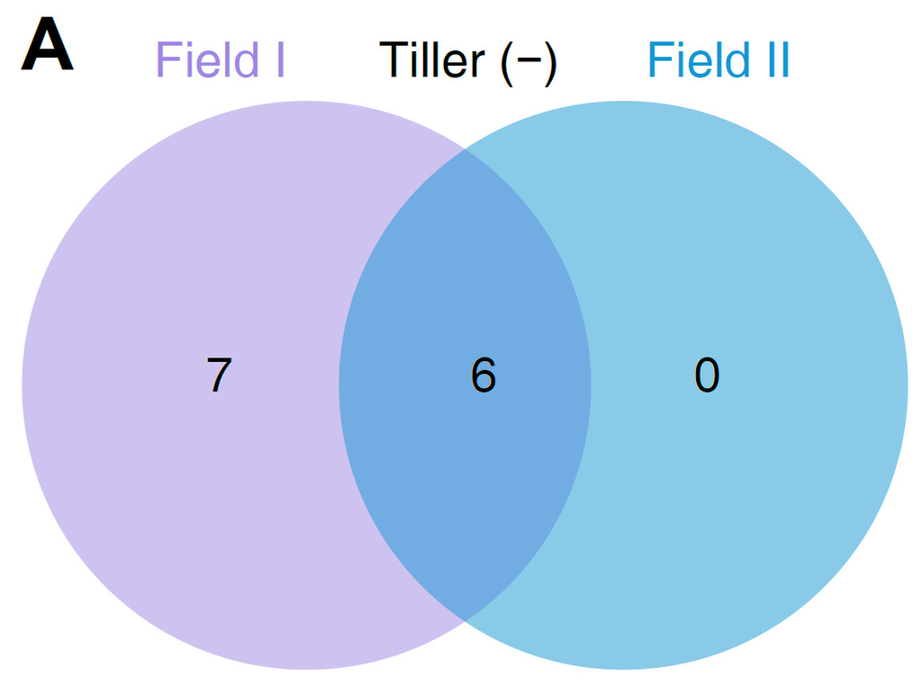

Overlap of bacterial genera negatively (A)

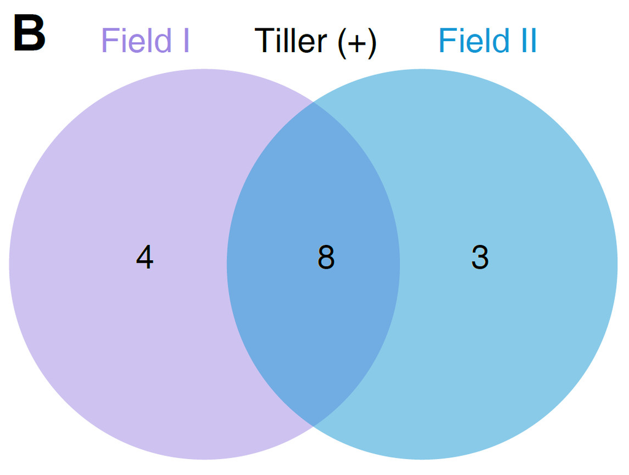

Overlap of bacterial genera positively (B)

```r
# Select overlap part
idx = (LN$FDR < 0.05 & HN$FDR < 0.05) & (LN$rho * HN$rho > 0)
table(idx)
```

```
idx
FALSE  TRUE
   23    14
```

```r
LN$env = "Positive"
LN[LN$rho<0,]$env = "Negative"
colnames(LN)[1] = "CorType"
table(LN[idx,]$CorType)
```

```
Negative Positive
       6        8
```

```r
# save list
write.table("OTUID\t", file=paste("../data/genus_list_1sig_simCor_2dot.txt",sep = ""), append = F, sep="\t", quote=F,  eol = "",row.names=F, col.names=F)
suppressWarnings(write.table(LN[idx,], file=paste("../data/genus_list_1sig_simCor_2dot.txt",sep = ""), append = T, sep="\t", quote=F, row.names=T, col.names=T))
```

(A-B) Overlap of bacterial genera negatively (A) or positively (B) correlated with tiller numbers of rice varieties grown in the two test fields.

## 3C. Spearman correlation coefficients of 14 abundant root bacterial genera

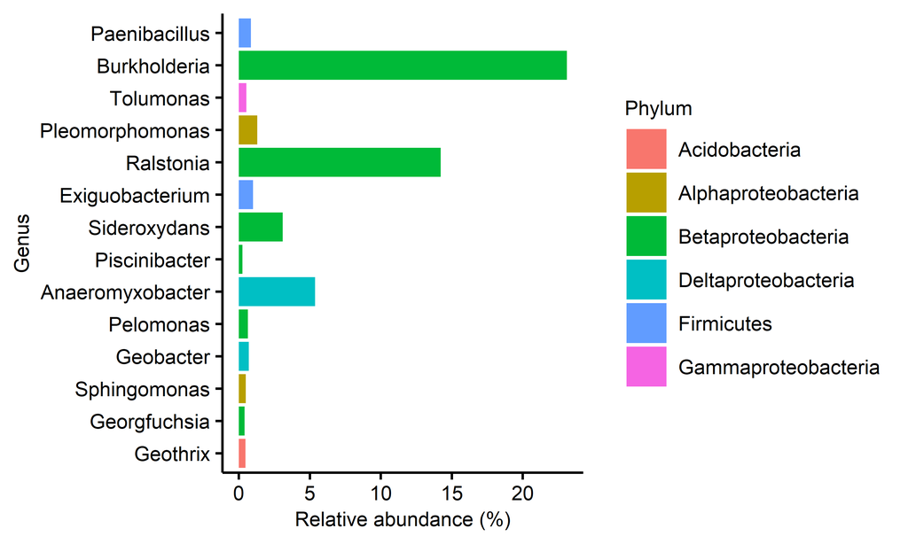

```r
library(dplyr)
tax = read.table("../data/taxonomy.txt", header=T, row.names =1, sep="\t", comment.char="", stringsAsFactors = F)
# Split Proteobacteria phylum into class
idx = tax$Phylum %in% "Proteobacteria"
tax[idx,]$Phylum = tax[idx,]$Class
# Select Phylum-Genus
tax =  tax[,c(2,6)]
# Dereplicate, 5K into 5 hundard
tax = dplyr::distinct(tax)

# reorder
# cor = as.data.frame(dplyr::arrange(cor, desc(rhotype), mean))
cor = read.table("3E.LN_genus_MSE_tax.txt", header=T, row.names =1, sep="\t", comment.char="", stringsAsFactors = F)
rownames(cor) = cor$OTUID
cor$OTUID = factor(cor$OTUID, levels = rownames(cor))

# Select correlated genus
idx =  tax$Genus %in% rownames(cor)
tax = tax[idx,]
# tax = rbind(tax, c("Unassigned", "Unassigned"))
rownames(tax) = tax$Genus

cor$Phylum = tax[rownames(cor),]$Phylum

# plot RA of genus
(p = ggplot(cor, aes(x = OTUID, y=mean, fill=Phylum)) +   geom_bar(stat = "identity") +
  coord_flip() + main_theme + theme(legend.position = "right") + xlab("Genus") + ylab("Relative abundance (%)"))
```

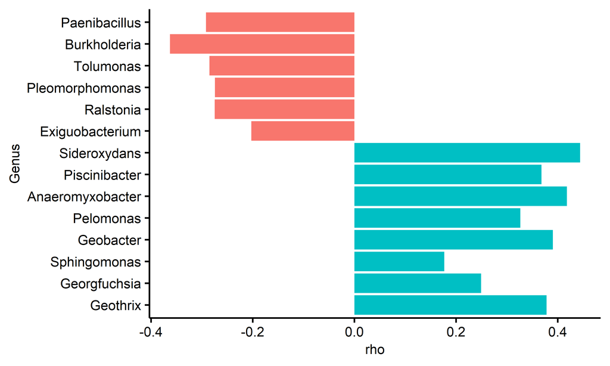

```r
ggsave(paste("3C.LN_genus_abundance_tax.pdf", sep=""), p, width = w*1.3, height = h*1.51, units = "mm")

# plot cor
(p = ggplot(cor, aes(x = OTUID, y=rho, fill=rhotype)) +   geom_bar(stat = "identity") +
  coord_flip() + main_theme+ theme(legend.position = "none")+ xlab("Genus"))
```

```r
ggsave(paste("3C.LN_genus_cor.pdf", sep=""), p, width = w*0.75, height = h*1.5, units = "mm")

min(cor$mean)
```

```
[1] 0.2489053
```

```r
max(cor$mean)
```

```
[1] 23.10425
```

```r
write.table("OTUID\t", file=paste("3C.LN_genus_tax_cor.txt",sep = ""), append = F, sep="\t", quote=F,  eol = "",row.names=F, col.names=F)
suppressWarnings(write.table(cor, file=paste("3C.LN_genus_tax_cor.txt",sep = ""), append = T, sep="\t", quote=F, row.names=T, col.names=T))
```

3. Bar plots showing the Spearman correlation coefficients of 14 abundant root bacterial genera that significantly correlated with rice tiller number (false discovery rate (FDR) adjusted P < 0.05).

## 3D. Heatmap showing the patterns of z-scored relative abundances of root bacterial genera

```r
genus = read.table(paste("../data/cultivar_LN_genus.txt",sep=""), header=T, row.names=1, sep="\t", comment.char="")
# norm to %
genus = as.data.frame(t(t(genus)/colSums(genus,na=T)*100))
mean(colSums(genus))
```

```
[1] 100
```

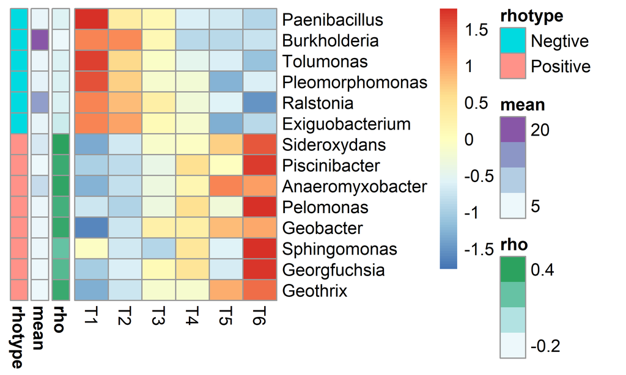

```r
pheno = read.table("../data/cultivar_LN_pheno.txt", header=T, row.names=1, sep="\t", comment.char="")

cor = read.table("3E.LN_genus_MSE_tax.txt", header=T, row.names =1, sep="\t", comment.char="", stringsAsFactors = F)
# Sort by abundance
cor = as.data.frame(dplyr::arrange(cor, rhotype, desc(IncMSE )))
rownames(cor) = cor$OTUID
cor$OTUID = factor(cor$OTUID, levels = rownames(cor))

# Select cor genus
df = genus[rownames(cor),]
metadata = read.table(paste("../data/cultivar_LN_metadata.txt",sep = ""), header=T, row.names=1, sep="\t", comment.char="")
idx = rownames(metadata) %in% colnames(genus)
metadata = metadata[idx,]
df = df[,rownames(metadata)]

# group by tiller number ranger
merge = cbind(t(df), metadata[,"tiller_cat", drop=F])
tiller_cat = merge %>% group_by(tiller_cat) %>% summarise_all(mean)
tiller_cat = as.data.frame(tiller_cat)
rownames(tiller_cat) = tiller_cat[,1]
tiller_cat = as.data.frame(t(tiller_cat[,-1]))

# plot heatmap
p = pheatmap(tiller_cat[rownames(cor),], cluster_rows = F, cluster_cols = F, scale = "row",
         annotation_row = cor[, c("rho", "mean","rhotype")])
```

```r
pheatmap(tiller_cat[rownames(cor),], cluster_rows = F, cluster_cols = F, scale = "row",
          border_color = "NA", # annotation_row = cor[, c("rho", "mean","rhotype")],
         filename = "3D.LN_genus_abundaceVStiller.pdf", fontsize = 8, width = h/25.4*1.8, height = h/25.4*1.5*0.97)
table(cor$rhotype)
```

```
 Negtive Positive
       6        8
```

```r
# save table
write.table("Genus\t", file=paste("3D.heatmap.txt",sep = ""), append = F, sep="\t", quote=F,  eol = "",row.names=F, col.names=F)
suppressWarnings(write.table(tiller_cat[rownames(cor),], file=paste("3D.heatmap.txt",sep = ""), append = T, sep="\t", quote=F, row.names=T, col.names=T))
```

4. Heatmap showing the patterns of z-scored relative abundances of root bacterial genera (C) in rice varieties within the tiller number ranges.

## 3E. The contribution of the 14 root bacterial genera (C) to the prediction of rice tiller numbers by a random forest

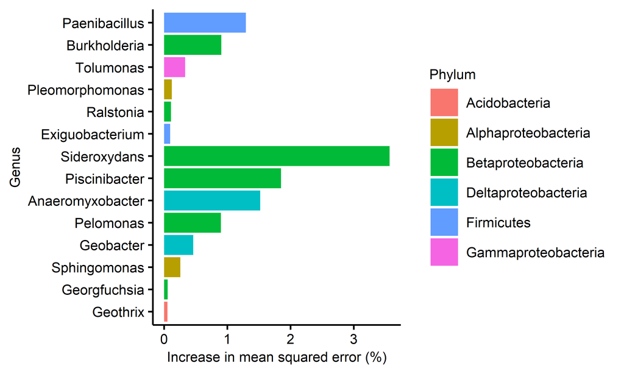

```r
library(dplyr)
imp = read.table("LN_importance_genus4.txt", header=T, row.names =1, sep="\t", comment.char="", stringsAsFactors = F)
cor = read.table("LN_cor_sort.txt", header=T, row.names =1, sep="\t", comment.char="", stringsAsFactors = F)
tax = read.table("../data/taxonomy.txt", header=T, row.names =1, sep="\t", comment.char="", stringsAsFactors = F)
# Replace Proteobacteria Phylum into order
idx = tax$Phylum %in% "Proteobacteria"
tax[idx,]$Phylum = tax[idx,]$Class
# Select phylum - genus
tax =  tax[,c(2,6)]
# Remove redundancy, from 5000 to 500
tax = dplyr::distinct(tax)
# Select cor related annotation
idx =  tax$Genus %in% rownames(cor)
tax = tax[idx,]
tax = rbind(tax, c("Unassigned", "Unassigned"))
rownames(tax) = tax$Genus
# Add Phylum
cor$Phylum = tax[rownames(cor),]$Phylum
# Add importance
cor$IncMSE = imp[rownames(cor),]$X.IncMSE

# sort by correlation, second by importance or abundance
# cor = as.data.frame(dplyr::arrange(cor, desc(rhotype), mean))
cor = as.data.frame(dplyr::arrange(cor, desc(rhotype), IncMSE))
rownames(cor) = cor$OTUID
cor$OTUID = factor(cor$OTUID, levels = rownames(cor))

# Plot importance, color by Phylum
(p = ggplot(cor, aes(x = OTUID, y=IncMSE, fill=Phylum)) +   geom_bar(stat = "identity") +
  coord_flip() + main_theme + xlab("Genus") + ylab("Increase in mean squared error (%)")) #  + theme(legend.position = "right")
```

```r
ggsave(paste("3E.LN_genus_MSE_tax.pdf", sep=""), p, width = w*1.3, height = h*1.5, units = "mm")
suppressWarnings(write.table(cor, file=paste("3E.LN_genus_MSE_tax.txt",sep = ""), append = F, sep="\t", quote=F, row.names=T, col.names=T))
```

5. The contribution of the 14 root bacterial genera (C) to the prediction of rice tiller numbers by a random forest machine learning model. Note that all 14 genera positively contributed to the accuracy of the prediction model. Data obtained in the other test field showed the same trend (Figure S5).